# Personal Loan Campaign Modelling

```python
# Importing Libraries
import pandas as pd
import numpy as np
from matplotlib import pyplot as plt
import seaborn as sns
%matplotlib inline
import warnings
warnings.filterwarnings('ignore')

# Building the Model using Logistic Regression
from sklearn.linear_model import LogisticRegression
# imported to calculate accuracy measures and confusion matrix
from sklearn import metrics
from sklearn.metrics import confusion_matrix, recall_score, precision_score, f1_score, roc_auc_score,accuracy_score
```

```python
# Importing Dataset into a Dataframe
df_cust = pd.read_csv("Bank_Personal_Loan_Modelling.csv")
df_cust.head()
```

|  | ID | Age | Experience | Income | ZIP Code | Family | CCAvg | Education | Mortgage | Personal Loan | Securities Account | CD Account | Online | CreditCard |
| --- | --- | --- | --- | --- | --- | --- | --- | --- | --- | --- | --- | --- | --- | --- |
| 0 | 1 | 25 | 1 | 49 | 91107 | 4 | 1.6 | 1 | 0 | 0 | 1 | 0 | 0 | 0 |
| 1 | 2 | 45 | 19 | 34 | 90089 | 3 | 1.5 | 1 | 0 | 0 | 1 | 0 | 0 | 0 |
| 2 | 3 | 39 | 15 | 11 | 94720 | 1 | 1.0 | 1 | 0 | 0 | 0 | 0 | 0 | 0 |
| 3 | 4 | 35 | 9 | 100 | 94112 | 1 | 2.7 | 2 | 0 | 0 | 0 | 0 | 0 | 0 |
| 4 | 5 | 35 | 8 | 45 | 91330 | 4 | 1.0 | 2 | 0 | 0 | 0 | 0 | 0 | 1 |

```python
#Applying info on the dataframe to see what is the nature of the data/datatypes
df_cust.info()
```

```
<class 'pandas.core.frame.DataFrame'>
RangeIndex: 5000 entries, 0 to 4999
Data columns (total 14 columns):
 #   Column              Non-Null Count  Dtype
---  ------              --------------  -----
 0   ID                  5000 non-null   int64
 1   Age                 5000 non-null   int64
 2   Experience          5000 non-null   int64
 3   Income              5000 non-null   int64
 4   ZIP Code            5000 non-null   int64
 5   Family              5000 non-null   int64
 6   CCAvg               5000 non-null   float64
 7   Education           5000 non-null   int64
 8   Mortgage            5000 non-null   int64
 9   Personal Loan       5000 non-null   int64
 10  Securities Account  5000 non-null   int64
 11  CD Account          5000 non-null   int64
 12  Online              5000 non-null   int64
 13  CreditCard          5000 non-null   int64
dtypes: float64(1), int64(13)
memory usage: 547.0 KB
```

```python
# Checking for number of rows and columns
df_cust.shape
```

```
(5000, 14)
```

Dataset has 5000 rows and 14 columns

```python
# getting a statistical summary column-wise, which includes the 5 point summary
df_cust.describe().transpose()
```

|  | count | mean | std | min | 25% | 50% | 75% | max |
| --- | --- | --- | --- | --- | --- | --- | --- | --- |
| ID | 5000.0 | 2500.500000 | 1443.520003 | 1.0 | 1250.75 | 2500.5 | 3750.25 | 5000.0 |
| Age | 5000.0 | 45.338400 | 11.463166 | 23.0 | 35.00 | 45.0 | 55.00 | 67.0 |
| Experience | 5000.0 | 20.104600 | 11.467954 | -3.0 | 10.00 | 20.0 | 30.00 | 43.0 |
| Income | 5000.0 | 73.774200 | 46.033729 | 8.0 | 39.00 | 64.0 | 98.00 | 224.0 |
| ZIP Code | 5000.0 | 93152.503000 | 2121.852197 | 9307.0 | 91911.00 | 93437.0 | 94608.00 | 96651.0 |
| Family | 5000.0 | 2.396400 | 1.147663 | 1.0 | 1.00 | 2.0 | 3.00 | 4.0 |
| CCAvg | 5000.0 | 1.937938 | 1.747659 | 0.0 | 0.70 | 1.5 | 2.50 | 10.0 |
| Education | 5000.0 | 1.881000 | 0.839869 | 1.0 | 1.00 | 2.0 | 3.00 | 3.0 |
| Mortgage | 5000.0 | 56.498800 | 101.713802 | 0.0 | 0.00 | 0.0 | 101.00 | 635.0 |
| Personal Loan | 5000.0 | 0.096000 | 0.294621 | 0.0 | 0.00 | 0.0 | 0.00 | 1.0 |
| Securities Account | 5000.0 | 0.104400 | 0.305809 | 0.0 | 0.00 | 0.0 | 0.00 | 1.0 |
| CD Account | 5000.0 | 0.060400 | 0.238250 | 0.0 | 0.00 | 0.0 | 0.00 | 1.0 |
| Online | 5000.0 | 0.596800 | 0.490589 | 0.0 | 0.00 | 1.0 | 1.00 | 1.0 |
| CreditCard | 5000.0 | 0.294000 | 0.455637 | 0.0 | 0.00 | 0.0 | 1.00 | 1.0 |

Experience columns has negetive values that we will need to replace

```python
df_cust.isnull().values.any() # Checking if there are any null values in data set
# Also the below can be used to see column-wise nulls if any (if 0 no nulls, else the count of nulls in the column)
# df_cust.isnull().sum()
```

```
False
```

No Nulls in the dataset

```python
# There are -ve values in the experience column and it does not make sense, checking for the distribution of Experience Column
print(df_cust.Experience[df_cust.Experience<0].describe()) #for Experience less than 0
print(df_cust.Experience[df_cust.Experience>=0].describe()) #for Experience more than and equal to 0
```

```
count    52.000000
mean     -1.442308
std       0.639039
min      -3.000000
25%      -2.000000
50%      -1.000000
75%      -1.000000
max      -1.000000
Name: Experience, dtype: float64
count    4948.000000
mean       20.331043
std        11.311973
min         0.000000
25%        10.750000
50%        20.000000
75%        30.000000
max        43.000000
Name: Experience, dtype: float64
```

Range and distribution of values greater than and equal to 0 indicates the negetive values might have been wrongly indicated as negetive. Flipping the sign of these negetive values to hold the same weight but on the positive side.

```python
# Flipping the signage of the -ve values in Experience column
df_cust.Experience[df_cust.Experience<0] = df_cust.Experience[df_cust.Experience<0] * -1
```

The dataset we have now is ready for further analysis in way of EDA

```python
# Number of unique in all columns
df_cust.nunique()
```

```
ID                    5000
Age                     45
Experience              44
Income                 162
ZIP Code               467
Family                   4
CCAvg                  108
Education                3
Mortgage               347
Personal Loan            2
Securities Account       2
CD Account               2
Online                   2
CreditCard               2
dtype: int64
```

```python
# Finding number of people with zero mortgage
df_cust.Mortgage[df_cust.Mortgage==0].count()
```

```
3462
```

```python
# Number of people with zero credit card spending per month
df_cust.CCAvg[df_cust.CCAvg==0].count()
```

```
106
```

```python
# Value counts of all categorical columns. NaN signifies value is not present for that category
# Not considering Zipcode as a category as it seems to be redundant to consider it in this case
df_cust[["Family", "Education", "Personal Loan", "Securities Account", "CD Account", "Online", "CreditCard"]].apply(pd.Series.value_counts)
```

|  | Family | Education | Personal Loan | Securities Account | CD Account | Online | CreditCard |
| --- | --- | --- | --- | --- | --- | --- | --- |
| 0 | NaN | NaN | 4520.0 | 4478.0 | 4698.0 | 2016.0 | 3530.0 |
| 1 | 1472.0 | 2096.0 | 480.0 | 522.0 | 302.0 | 2984.0 | 1470.0 |
| 2 | 1296.0 | 1403.0 | NaN | NaN | NaN | NaN | NaN |
| 3 | 1010.0 | 1501.0 | NaN | NaN | NaN | NaN | NaN |
| 4 | 1222.0 | NaN | NaN | NaN | NaN | NaN | NaN |

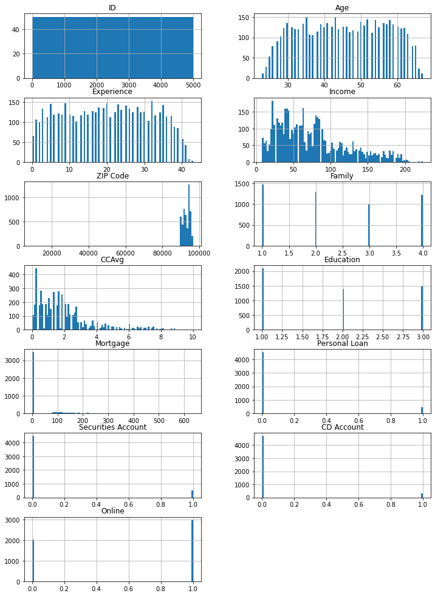

```python
# Plotting Histogram to get an idea of the distribution
columns = list(df_cust)[0:-1]
df_cust[columns].hist(stacked=False, bins=100, figsize=(12,35), layout=(14,2));
```

```python
# Mean analysis wrt to target variable
df_cust.groupby("Personal Loan").mean()
```

| Personal Loan | ID | Age | Experience | Income | ZIP Code | Family | CCAvg | Education | Mortgage | Securities Account | CD Account | Online | CreditCard |
| --- | --- | --- | --- | --- | --- | --- | --- | --- | --- | --- | --- | --- | --- |
| 0 | 2512.165487 | 45.367257 | 20.165487 | 66.237389 | 93152.428761 | 2.373451 | 1.729009 | 1.843584 | 51.789381 | 0.102212 | 0.035841 | 0.595796 | 0.293584 |
| 1 | 2390.650000 | 45.066667 | 19.843750 | 144.745833 | 93153.202083 | 2.612500 | 3.905354 | 2.233333 | 100.845833 | 0.125000 | 0.291667 | 0.606250 | 0.297917 |

```python
# Median analysis wrt to target variable
df_cust.groupby("Personal Loan").median()
```

| Personal Loan | ID | Age | Experience | Income | ZIP Code | Family | CCAvg | Education | Mortgage | Securities Account | CD Account | Online | CreditCard |
| --- | --- | --- | --- | --- | --- | --- | --- | --- | --- | --- | --- | --- | --- |
| 0 | 2518.5 | 45.0 | 20.0 | 59.0 | 93437.0 | 2.0 | 1.4 | 2.0 | 0.0 | 0.0 | 0.0 | 1.0 | 0.0 |
| 1 | 2342.0 | 45.0 | 20.0 | 142.5 | 93407.0 | 3.0 | 3.8 | 2.0 | 0.0 | 0.0 | 0.0 | 1.0 | 0.0 |

**Insights:** Some trends are showing from the mean and median analysis

- We can some correlation between families with higher income and people who opt for personal loans.
- Families with higher CCAvg are more likely to take a personal Loan.

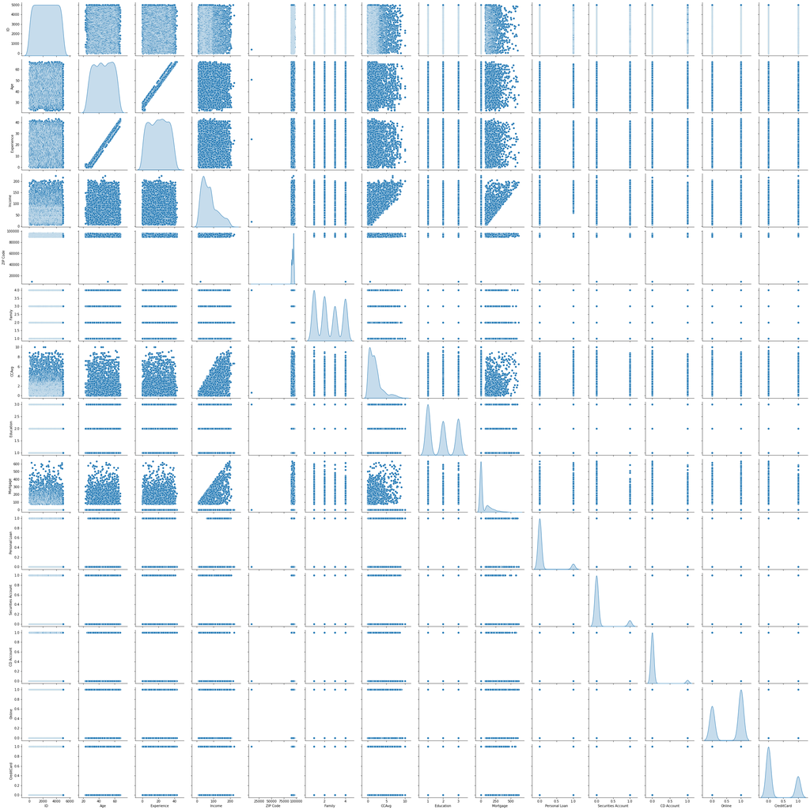

```python
sns.pairplot(df_cust, diag_kind='kde')
```

**Insights:** From the univariate and bivariate distributions we can see that the columns id and zipcode add no significant value for this problem statement. Id is a sequential number and zip code is a categorical variable which does contribute to making any predictions in this case (zip code has a limited spread and looks like the sample is from a particular area).

```python
# Replacing Education with actual level of eduction to perform one-hot encoding
df_cust.Education = df_cust.Education.replace({1:'Undergrad',2:'Graduate',3:'Advanced'})
df_cust.head()
```

|  | ID | Age | Experience | Income | ZIP Code | Family | CCAvg | Education | Mortgage | Personal Loan | Securities Account | CD Account | Online | CreditCard |
| --- | --- | --- | --- | --- | --- | --- | --- | --- | --- | --- | --- | --- | --- | --- |
| 0 | 1 | 25 | 1 | 49 | 91107 | 4 | 1.6 | Undergrad | 0 | 0 | 1 | 0 | 0 | 0 |
| 1 | 2 | 45 | 19 | 34 | 90089 | 3 | 1.5 | Undergrad | 0 | 0 | 1 | 0 | 0 | 0 |
| 2 | 3 | 39 | 15 | 11 | 94720 | 1 | 1.0 | Undergrad | 0 | 0 | 0 | 0 | 0 | 0 |
| 3 | 4 | 35 | 9 | 100 | 94112 | 1 | 2.7 | Graduate | 0 | 0 | 0 | 0 | 0 | 0 |
| 4 | 5 | 35 | 8 | 45 | 91330 | 4 | 1.0 | Graduate | 0 | 0 | 0 | 0 | 0 | 1 |

```python
# Applying one hot encoding
df_cust = pd.get_dummies(df_cust, columns=['Education'])
```

```python
# Correlation Heatmap function
def plot_corr(df, size=11):
    corr = df.corr()
    fig, ax = plt.subplots(figsize=(size, size))
    ax.matshow(corr)
    plt.xticks(range(len(corr.columns)), corr.columns)
    plt.yticks(range(len(corr.columns)), corr.columns)
    for (i, j), z in np.ndenumerate(corr):
        ax.text(j, i, '{:0.1f}'.format(z), ha='center', va='center')
```